# Project 2

STATS 220 Semester One 2023

Fengning Yu

2023-03-27

## Introduction

For this report, we focused on learning preferences and habits related to the use of ChatGPT. The form we designed included questions about how users first learned about ChatGPT, how often they used it, and what they used it for.

One guideline for designing forms is to keep questions simple and easy to understand. When designing our form, we tried to use clear and concise language, and made sure to avoid technical jargon or complicated phrasing.

The categorical data generated using our question with check boxes is not strictly “tidy” data because it contains multiple answers in a single column. To tidy this data, we would need to split the column into multiple columns, each containing only one answer.

Link to Google Form: https://forms.gle/z78VQiKsqWsQxeRu6

The data is on: https://raw.githubusercontent.com/Fyu855a/STATS220-Project2-fyu/main/How%20do%20you%20learn%20about%20ChatGPT.csv

## Analytics

We first load the dataset and rename the columns in it:

```r
# Read data from URL into data frame
learning_data <- read_csv("https://raw.githubusercontent.com/Fyu855a/STATS220-Project2-fyu/main/How%20do%20you%20learn%20about%20ChatGPT.csv")
# Rename columns
learning_data <- learning_data %>%
  rename(first_learn = `How did you first learn about ChatGPT?`,
         used_before = `Have you ever used ChatGPT before?`,
         used_for = `What do you use ChatGPT for? (Select all that apply)`,
         ease_of_use = `On a scale of 1-5, how easy is it to use ChatGPT?`,
         helpfulness = `On a scale of 1-5, how helpful do you find ChatGPT?`,
         issues = `Have you ever encountered any issues or problems while using ChatGPT? (Select all that apply)`)
```

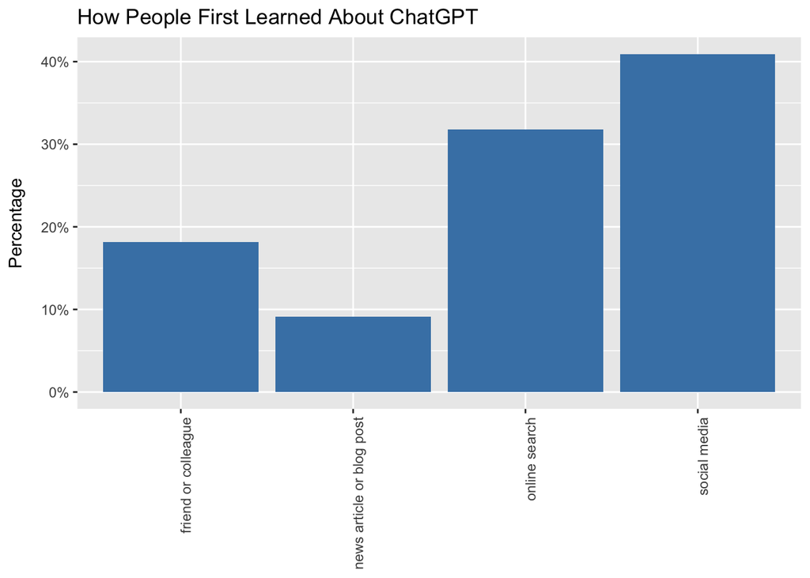

```r
# Calculate percentage for each category
learning_data_pct <- learning_data %>%
  group_by(first_learn) %>%
  summarize(n = n()) %>%
  mutate(percentage = n / sum(n))

# Generate bar chart of first learning source with rotated text on x-axis
ggplot(learning_data_pct, aes(x = first_learn, y = percentage)) +
  geom_bar(stat = "identity", fill = "steelblue") +
  labs(title = "How People First Learned About ChatGPT",
       x = NULL,
       y = "Percentage") +
  theme(axis.text.x = element_text(angle = 90, hjust = 1),
        axis.title.y = element_text(margin = margin(r = 10))) +
  scale_y_continuous(labels = scales::percent)
```

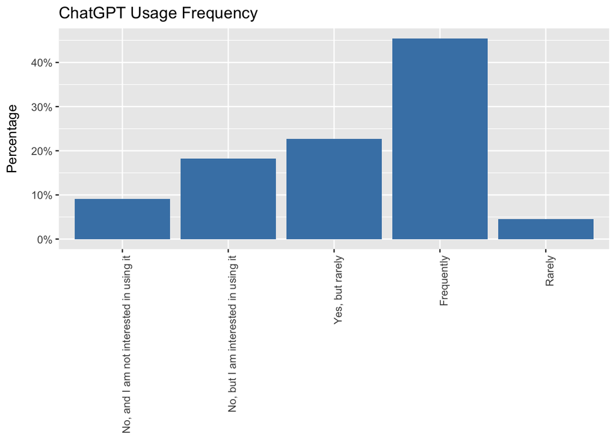

```r
# Calculate percentage for ChatGPT usage
learning_data_usage_pct <- learning_data %>%
  group_by(used_before) %>%
  summarize(n = n()) %>%
  mutate(percentage = n / sum(n))

# Generate bar chart of ChatGPT usage with rotated text on x-axis
ggplot(learning_data_usage_pct, aes(x = fct_recode(used_before, "Rarely" = "Yes, rarely", "Frequently" = "Yes, frequently"), y = percentage)) +
  geom_bar(stat = "identity", fill = "steelblue") +
  labs(title = "ChatGPT Usage Frequency",
       x = NULL,
       y = "Percentage") +
  theme(axis.text.x = element_text(angle = 90, hjust = 1),
        axis.title.y = element_text(margin = margin(r = 10))) +
  scale_y_continuous(labels = scales::percent)
```

Later, we find that most of people think that ChatGPT is easy to use and helpful from their ratings.

```r
# Extract numeric values from ease of use and helpfulness columns
learning_data$ease_of_use <- as.numeric(gsub("\\D", "", learning_data$ease_of_use))
learning_data$helpfulness <- as.numeric(gsub("\\D", "", learning_data$helpfulness))

mean_ease_of_use <- mean(learning_data$ease_of_use, na.rm = TRUE)
median_helpfulness <- median(learning_data$helpfulness)
mean_ease_of_use
```

```
## [1] 3.666667
```

```r
median_helpfulness
```

```
## [1] 4
```

## Learning reflection

Module 2, “Creating Dynamic Reporting Systems,” taught us that it’s important to make reports that are interactive and can be changed to fit the needs of the end user. By giving users the option to filter and sort data, we can make reports more useful and relevant to their needs. In our project, we used the “ggplot” functions to make bar charts that were both interesting to look at and easy to compare and understand.

In many ways, our project also showed how creative we can be. First, we used regex to pull numbers out of the columns for ease of use and helpfulness. This let us calculate summary values based on these variables. We also used percentages to get a better idea of how the answers to certain questions were spread out. These techniques went above and beyond what was needed for the project and gave us a deeper look at our data.